# WITM

2024-08-14

#WITM Analysis - section 1 - v2

**-.-.-.-.-.-.-.-.-.-.-.-.-.-.-.-.-.-.-.-.-.-.-.-.-.-.-.-.-.-**

This report filters only people who answered Q0=yes (i.e. who agree to answer the survey) and does not filter on question q1.

```r
# OPEN CSV file
witm <- read.csv2("Data/WITM_csv_last.csv")

source(file="WITM_variables.R")

print(date())
```

```
## [1] "Wed Aug 14 07:54:09 2024"
```

**-.-.-.-.-.-.-.-.-.-.-.-.-.-.-.-.-.-.-.-.-.-.-.-.-.-.-.-.-.-**

**Number of answers by date**

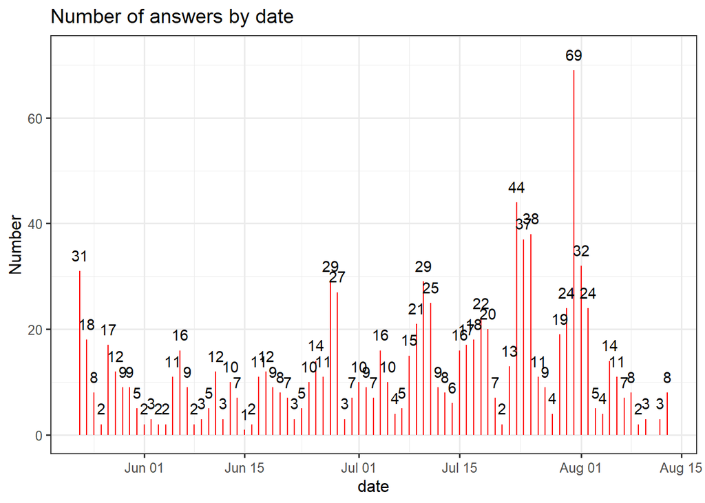

**-.-.-.-.-.-.-.-.-.-.-.-.-.-.-.-.-.-.-.-.-.-.-.-.-.-.-.-.-.-**

**Group information:**

Q2. Which of the following statements best describes your group, organization and/or movement?

| Description | n | porcentaje |
| --- | --- | --- |
| We promote the rights of women or girls or trans or gender diverse people with intersecting identities ‘through specific project(s)’, but not as the primary focus of our work | 190 | 19.2 |
| We promote the rights of women or girls or trans or gender diverse people in all their intersecting identities and this is the ‘primary focus of all our work’ | 732 | 73.9 |
| Other | 69 | 7.0 |

**-.-.-.-.-.-.-.-.-.-.-.-.-.-.-.-.-.-.-.-.-.-.-.-.-.-.-.-.-.-**

**Organization names:**

Q3. The name of your group, organization and/or movement

```
## [1] "The number of organisations that did not answer their name is: 67"
```

**–Analysis notes———————————————————————–**

Very interesting that almost all organisations responded with their name despite the fact that the possibility of not responding is informed and underlined.

**-.-.-.-.-.-.-.-.-.-.-.-.-.-.-.-.-.-.-.-.-.-.-.-.-.-.-.-.-.-**

**Type of organization**

Q4. Which of the following forms of organizing best describes your group, organization and/or movement?

*This is a multiple-choice question so the sum of the % does NOT add up to 100.*

| Organization type | n | porcentaje |
| --- | --- | --- |
| Women’s rights | 745 | 75.2 |
| Ending gender based violence | 686 | 69.2 |
| Human rights | 569 | 57.4 |
| Sexual and reproductive health & rights (SRHR) and bodily autonomy | 548 | 55.3 |
| Young feminists | 373 | 37.6 |
| Economic justice, rights and alternatives | 336 | 33.9 |
| Climate and environmental justice | 319 | 32.2 |
| Human rights defenders at risk | 307 | 31.0 |
| Girls’ movements | 276 | 27.9 |
| Lesbian, Bisexual and queer rights | 248 | 25.0 |
| Disability rights and justice | 238 | 24.0 |
| Countering anti-gender and anti-rights | 234 | 23.6 |
| Rights for people living with HIV+ | 221 | 22.3 |
| Sex workers rights | 214 | 21.6 |
| Indigenous rights | 211 | 21.3 |
| Holistic safety, protection and collective care | 210 | 21.2 |
| Displaced, migrant and refugee rights | 205 | 20.7 |
| Trans and non-binary rights | 189 | 19.1 |
| Crisis response | 184 | 18.6 |
| Labour rights | 172 | 17.4 |
| Black rights/ Black feminist rights | 153 | 15.4 |
| Digital rights | 152 | 15.3 |
| Freedom of information and media | 127 | 12.8 |
| Pleasure and bodily care | 122 | 12.3 |
| Racial justice | 121 | 12.2 |
| Harm reduction | 118 | 11.9 |
| Intersex rights | 100 | 10.1 |
| Anti-militarization and peace | 95 | 9.6 |
| Religious and ethnic minority rights | 92 | 9.3 |
| Other | 53 | 5.3 |
| Resisting the war on drugs | 47 | 4.7 |
| Anti-caste | 31 | 3.1 |

**Type of organization - grouped (q4_grouped)**

This variable is constructed by recognizing the organizations that work on one of AWID’s focus topics and those that do not, are placed as “other subjects (not focus)”.

- Lesbian, bisexual and queer rights
- Sex workers rights
- Trans and non-binary-rights
- Anti-caste
- Climate and environmental justice
- Countering anti-gender and anti-rights
- Anti-militarization and peace
- Holistic safety, protection and collective care

| q4_awid_focus | n | percentage |
| --- | --- | --- |
| Other subjects | 292 | 29.5 |
| Specific AWID subjects | 699 | 70.5 |

| Organization type | n | Percentage |
| --- | --- | --- |
| Climate and environmental justice | 319 | 32.2 |
| Other feminists subjects (not AWID focus) | 292 | 29.5 |
| Lesbian, Bisexual and queer rights | 248 | 25.0 |
| Countering anti-gender and anti-rights | 234 | 23.6 |
| Sex workers rights | 214 | 21.6 |
| Holistic safety, protection and collective care | 210 | 21.2 |
| Trans and non-binary rights | 189 | 19.1 |
| Anti-militarization and peace | 95 | 9.6 |
| Anti-caste | 31 | 3.1 |

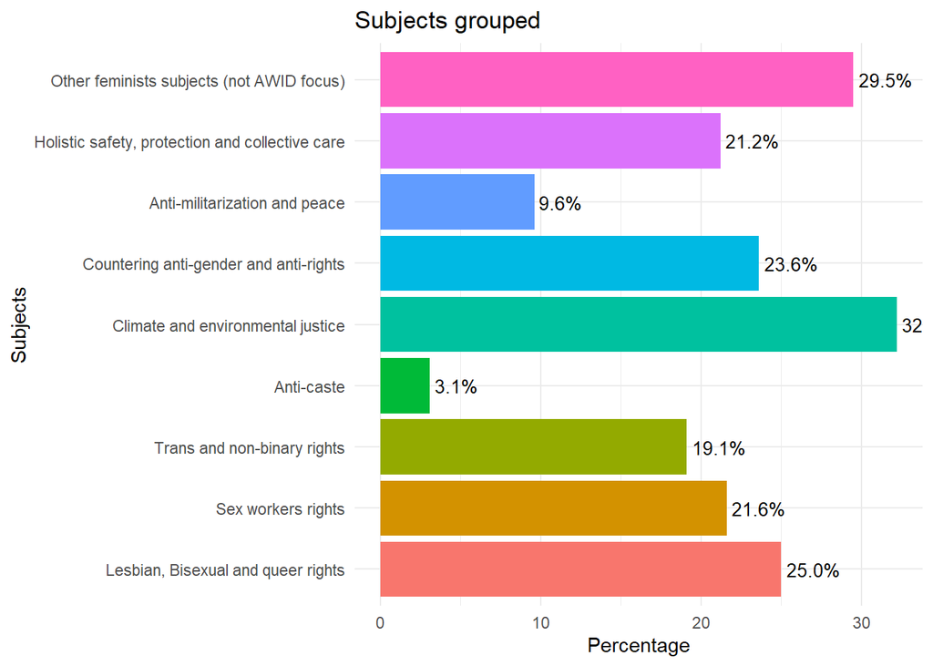

**-.-.-.-.-.-.-.-.-.-.-.-.-.-.-.-.-.-.-.-.-.-.-.-.-.-.-.-.-.-**

**Register**

Q5. Is your group, organization and/or movement registered?

| Register | n | Percentage |
| --- | --- | --- |
| Yes | 800 | 80.7 |
| No | 153 | 15.4 |
| Other | 27 | 2.7 |
| NA | 11 | 1.1 |

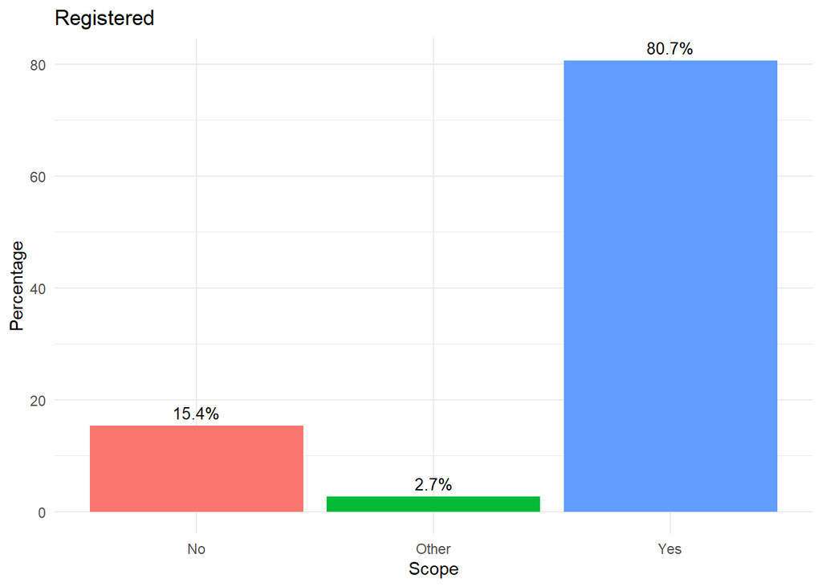

**-.-.-.-.-.-.-.-.-.-.-.-.-.-.-.-.-.-.-.-.-.-.-.-.-.-.-.-.-.-**

**Scope:**

Q6. What is the geographical scope of your work?

| q6_geo_scope | n | Percentage |
| --- | --- | --- |
| Nationally | 485 | 48.940464 |
| Locally | 320 | 32.290616 |
| Regionally | 97 | 9.788093 |
| Global | 59 | 5.953582 |
| Transnationally | 19 | 1.917255 |
| Diaspora | 11 | 1.109990 |

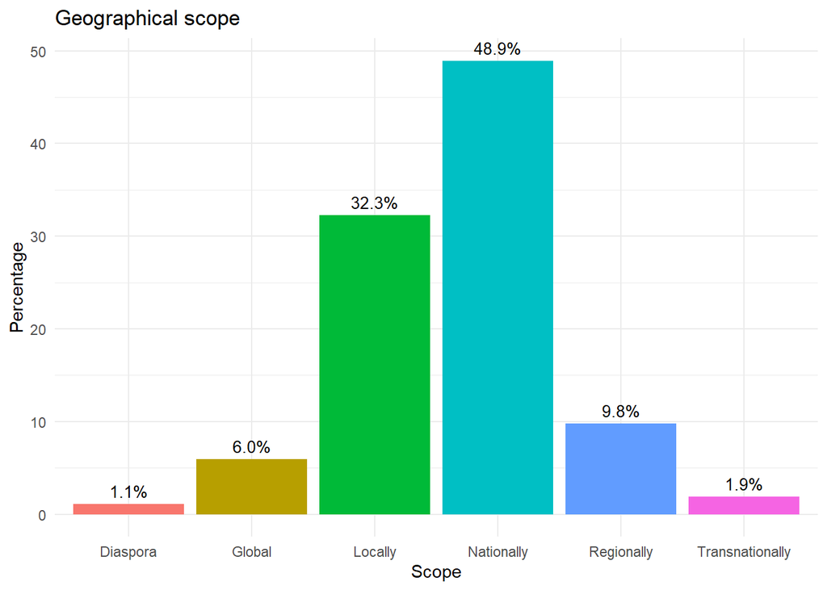

**Region:**

Q7. Indicate in which region(s) your group, organization and/or movement works

| Region | n | porcentaje |
| --- | --- | --- |
| East Africa | 163 | 106.5 |
| South America | 162 | 105.9 |
| South Asia | 143 | 93.5 |
| Central America & Mexico | 141 | 92.2 |
| West Africa | 128 | 83.7 |
| Central Africa | 94 | 61.4 |
| Southeast Asia | 84 | 54.9 |
| Southern Africa | 76 | 49.7 |
| Caribbean | 64 | 41.8 |
| Eastern Europe, Southeast Europe and Central Europe | 62 | 40.5 |
| South West Asia/Middle East | 61 | 39.9 |
| Western Europe | 60 | 39.2 |
| North Africa | 51 | 33.3 |
| North America | 48 | 31.4 |
| The Pacific | 41 | 26.8 |
| Central Asia & Caucasus | 30 | 19.6 |
| East Asia | 30 | 19.6 |

**-.-.-.-.-.-.-.-.-.-.-.-.-.-.-.-.-.-.-.-.-.-.-.-.-.-.-.-.-.-**

**Country:**

Q8. Which countries are you working in?

| q7_region_one | q8_country | n | Percentage |
| --- | --- | --- | --- |
| East Africa | Kenya | 39 | 32.8 |
| East Africa | South Sudan | 6 | 5.0 |
| East Africa | Uganda | 38 | 31.9 |
| East Africa | Rwanda | 9 | 7.6 |
| East Africa | Burundi | 5 | 4.2 |
| East Africa | Tanzania | 11 | 9.2 |
| East Africa | Malawi | 1 | 0.8 |
| East Africa | Mozambique | 1 | 0.8 |
| East Africa | Ethiopia | 3 | 2.5 |
| East Africa | Other East Africa | 3 | 2.5 |
| East Africa | Somalia | 2 | 1.7 |
| East Africa | NA | 1 | 0.8 |
| North America | United States of America | 7 | 36.8 |
| North America | Canada | 11 | 57.9 |
| North America | NA | 1 | 5.3 |
| Central Africa | Democratic Republic of the Congo | 44 | 68.8 |
| Central Africa | Cameroon | 10 | 15.6 |
| Central Africa | Central African Republic | 3 | 4.7 |
| Central Africa | Other Central Africa | 1 | 1.6 |
| Central Africa | Chad | 4 | 6.2 |
| Central Africa | Angola | 1 | 1.6 |
| Central Africa | NA | 1 | 1.6 |
| Southeast Asia | Thailand | 3 | 6.5 |
| Southeast Asia | Malaysia | 4 | 8.7 |
| Southeast Asia | Indonesia | 9 | 19.6 |
| Southeast Asia | Cambodia | 3 | 6.5 |
| Southeast Asia | Myanmar | 10 | 21.7 |
| Southeast Asia | Philippines | 6 | 13.0 |
| Southeast Asia | Other Southeast Asia | 6 | 13.0 |
| Southeast Asia | Viet Nam | 1 | 2.2 |

[output cut: 98 more lines]

**-.-.-.-.-.-.-.-.-.-.-.-.-.-.-.-.-.-.-.-.-.-.-.-.-.-.-.-.-.-**

**Year of formation:**

Q9. What year was your group, organization and/ or movement formed?

q9_year_formation_agrup

total

Percentage

1. 2021-2023

126

15.7

2. From 2015 to 2020

272

33.8

3. From 2010 to 2014

132

16.4

4. From 2000 to 2009

169

21.0

5. Before 2000

106

13.2

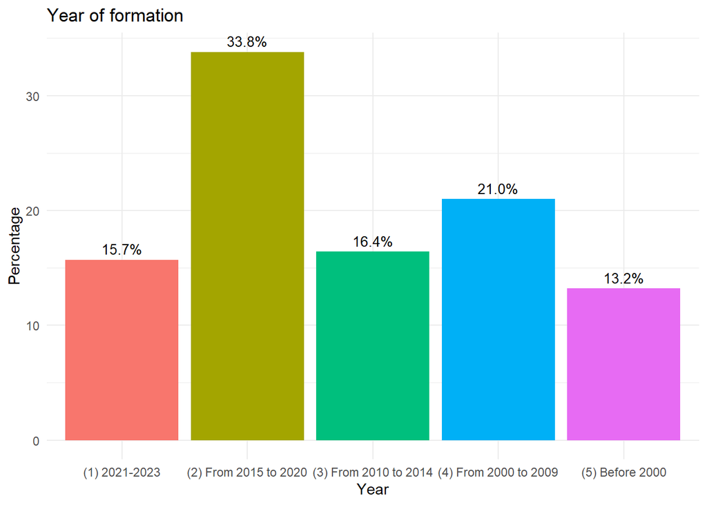

**-.-.-.-.-.-.-.-.-.-.-.-.-.-.-.-.-.-.-.-.-.-.-.-.-.-.-.-.-.-**

##CROSSTABS

**AWID FOCUS SUBJECTS BY REGISTRATION**

A crosstabulation (bivariate) of the combination of registration and subject of the organisation

[output not shown]

| q4_grouped | y_registered | n_registered |
| --- | --- | --- |
| Anti Caste | 65.4 | 34.6 |
| Anti-militarization and peace | 76.4 | 23.6 |
| Climate and environmental justice | 87.6 | 12.4 |
| Countering anti-gender and anti-rights | 77.1 | 22.9 |
| Holistic safety, protection and collective care | 80.2 | 19.8 |
| Lesbian, Bisexual and queer rights | 77.2 | 22.8 |
| Sex workers rights | 83.3 | 16.7 |
| Trans and non-binary rights | 73.2 | 26.8 |
| Other feminists subjects (not AWID focus) | 85.3 | 14.7 |

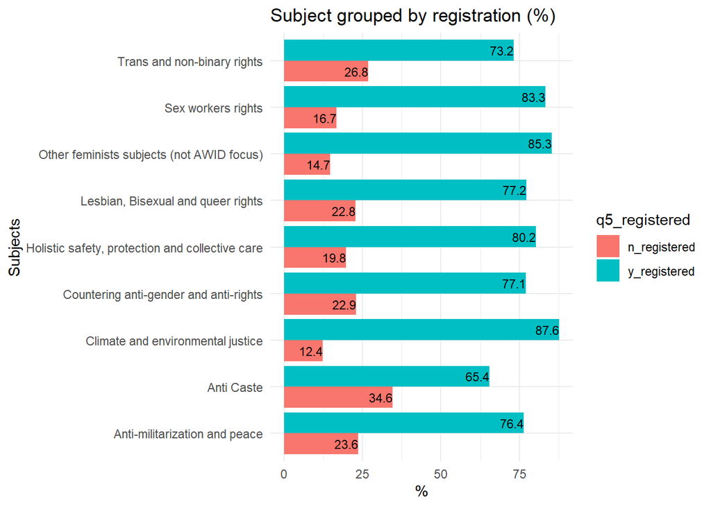

**-.-.-.-.-.-.-.-.-.-.-.-.-.-.-.-.-.-.-.-.-.-.-.-.-.-.-.-.-.-**

**SUBJECTS GROUPED BY SCOPE**

Percentage

| q4_grouped | nationally_focused | locally_focused |
| --- | --- | --- |
| Anti Caste | 3.1 | 3.8 |
| Anti-militarization and peace | 11.3 | 5.6 |
| Climate and environmental justice | 35.1 | 30.3 |
| Countering anti-gender and anti-rights | 25.6 | 19.1 |
| Holistic safety, protection and collective care | 22.7 | 17.8 |
| Lesbian, Bisexual and queer rights | 24.3 | 24.4 |
| Sex workers rights | 22.7 | 24.7 |
| Trans and non-binary rights | 20.8 | 15.6 |
| Other feminists subjects (not AWID focus) | 29.1 | 30.3 |
| total | 60.2 | 39.8 |

**–LECTURE———————————————————————–**

**—————————————————————————————–**

**-.-.-.-.-.-.-.-.-.-.-.-.-.-.-.-.-.-.-.-.-.-.-.-.-.-.-.-.-.-**

**SUBJECTS GROUPED BY SCOPE**

Absoluts numbers

| q4_grouped | nationally_focused | locally_focused |
| --- | --- | --- |
| Anti Caste | 15 | 12 |
| Anti-militarization and peace | 55 | 18 |
| Climate and environmental justice | 170 | 97 |
| Countering anti-gender and anti-rights | 124 | 61 |
| Holistic safety, protection and collective care | 110 | 57 |
| Lesbian, Bisexual and queer rights | 118 | 78 |
| Sex workers rights | 110 | 79 |
| Trans and non-binary rights | 101 | 50 |
| Other feminists subjects (not AWID focus) | 141 | 97 |
| total | 485 | 320 |

**-.-.-.-.-.-.-.-.-.-.-.-.-.-.-.-.-.-.-.-.-.-.-.-.-.-.-.-.-.-**

**SUBJECTS GROUPED BY SCOPE (NATIONAL AND LOCAL)**

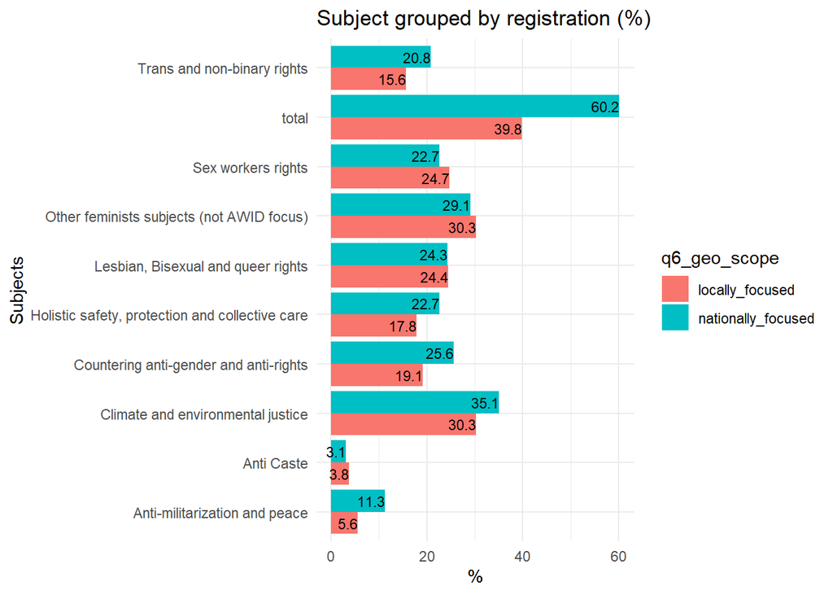

**-.-.-.-.-.-.-.-.-.-.-.-.-.-.-.-.-.-.-.-.-.-.-.-.-.-.-.-.-.-**

**SUBJECTS GROUPED BY YEAR OF FORMATION**

Percentage

[output not shown]

q4_grouped

1. 2021-2023
2. From 2015 to 2020
3. From 2010 to 2014
4. From 2000 to 2009
5. Before 2000

Anti Caste

25.9

48.1

7.4

7.4

11.1

Anti-militarization and peace

16.4

38.4

16.4

17.8

11.0

Climate and environmental justice

14.6

36.0

15.0

18.0

16.5

Countering anti-gender and anti-rights

19.5

31.9

13.5

21.1

14.1

Holistic safety, protection and collective care

17.4

38.9

13.8

16.8

13.2

Lesbian, Bisexual and queer rights

17.9

35.2

16.8

19.4

10.7

Sex workers rights

15.3

36.0

12.7

25.9

10.1

Trans and non-binary rights

19.9

38.4

14.6

17.9

9.3

Other feminists subjects (not AWID focus)

13.9

30.3

16.0

23.9

16.0

total

15.7

33.8

16.4

21.0

13.2

**–LECTURE———————————————————————–**

**—————————————————————————————–**

**-.-.-.-.-.-.-.-.-.-.-.-.-.-.-.-.-.-.-.-.-.-.-.-.-.-.-.-.-.-**

**Scope by registration**

A crosstabulation (bivariate) of the combination of registered and scope

| q5_registered | Nationally | Locally |
| --- | --- | --- |
| Registered | 85.2 | 77.1 |
| No registered | 13.1 | 20.1 |
| Other | 1.7 | 2.9 |

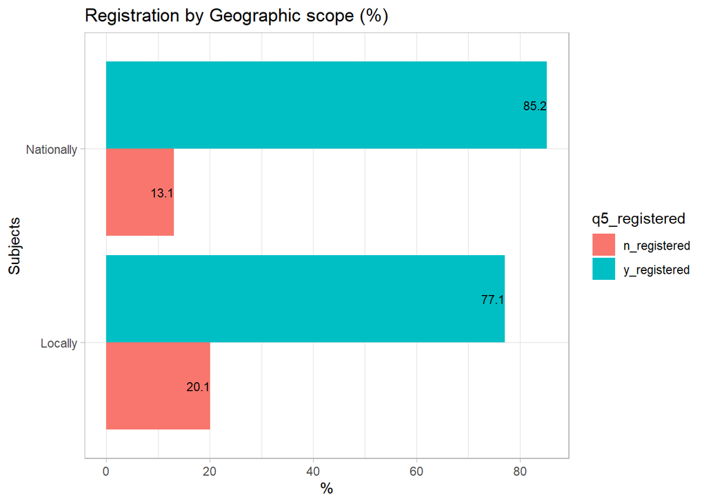

**–Lecture ———————————————————————–**

**————————————————————————————————**

**-.-.-.-.-.-.-.-.-.-.-.-.-.-.-.-.-.-.-.-.-.-.-.-.-.-.-.-.-.-**

**Region by register**

This is made now only for Locally and National organisations

| q5_registered | Registered | No registered |  | Other |
| --- | --- | --- | --- | --- |
| East Africa | 89.1 | 9.2 | 0.8 | 0.8 |
| South Asia | 90.0 | 8.2 | 0.9 | 0.9 |
| South America | 75.5 | 17.3 | 4.1 | 3.1 |
| West Africa | 82.9 | 12.2 | 2.4 | 2.4 |
| Central Africa | 95.3 | 3.1 | NA | 1.6 |
| Central America & Mexico | 66.7 | 30.7 | NA | 2.7 |
| Southern Africa | 85.7 | 14.3 | NA | NA |
| Southeast Asia | 73.9 | 19.6 | NA | 6.5 |
| Caribbean | 74.1 | 22.2 | NA | 3.7 |
| Western Europe | 90.9 | 9.1 | NA | NA |
| Eastern Europe, Southeast Europe and Central Europe | 81 | 19 | NA | NA |
| South West Asia/Middle East | 57.7 | 42.3 | NA | NA |
| North America | 63.2 | 26.3 | NA | 10.5 |
| The Pacific | 75.0 | 12.5 | 6.2 | 6.2 |
| North Africa | 60 | 35 | 5 | NA |
| Central Asia & Caucasus | 100 | NA | NA | NA |
| East Asia | 77.8 | 22.2 | NA | NA |

**–Analysis notes———————————————————————–**

**————————————————————————————————**

**-.-.-.-.-.-.-.-.-.-.-.-.-.-.-.-.-.-.-.-.-.-.-.-.-.-.-.-.-.-**

**Year of formation & Register**

q5_registered

1. 2021-2023
2. From 2015 to 2020
3. From 2010 to 2014
4. From 2000 to 2009
5. Before 2000

No registered

35.6

22.6

12.5

3.6

2.9

Registered

64.4

77.4

87.5

96.4

97.1

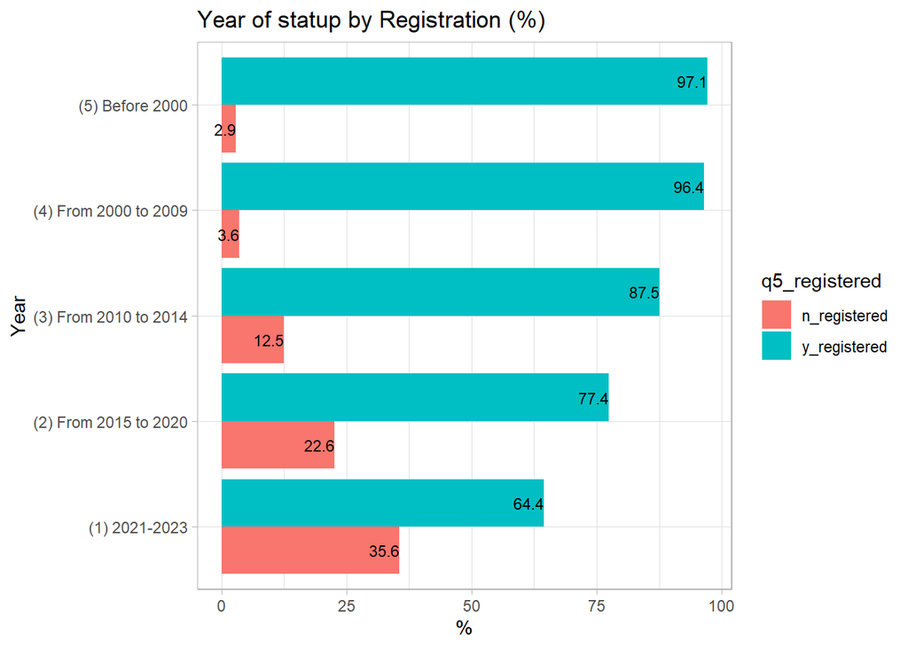

**–Lecture———————————————————————-**

Organizations starting in the last 3 years have a high proportion of non-registration. It decreases as the start-up time passes.

**————————————————————————————————**

**-.-.-.-.-.-.-.-.-.-.-.-.-.-.-.-.-.-.-.-.-.-.-.-.-.-.-.-.-.-**

**Year by Gegraphically Scope**

```
## # A tibble: 2 × 2
##   q6_geo_scope           n
##   <chr>              <int>
## 1 locally_focused      320
## 2 nationally_focused   485
```

q6_geo_scope

1. 2021-2023
2. From 2015 to 2020
3. From 2010 to 2014
4. From 2000 to 2009
5. Before 2000

Locally

19.1

35.6

17.2

17.2

10.9

Nationally

13.4

32.6

15.9

23.5

14.6